# week 4 homework

2026-11-05

## 0. Analysis plan

Research question: How did gender inequality (GII) change between 2010 and 2019 across the world?

1. Load the UNDP HDR composite indices (CSV) and world country boundaries (GeoJSON).
2. Keep the country code and GII for 2010 and 2019, and calculate the change (2019 minus 2010). A negative value means inequality fell.
3. Convert the 3-letter country codes to 2-letter codes with `countrycode`, so they match the map.
4. Join the GII table to the world map using the country code (a unique ID, not the country name).
5. Map the change with a diverging colour scheme centred on 0.

## 1. Load data

```r
# packages: tidyverse (data cleaning), sf (spatial data),
# janitor (tidy column names), countrycode (convert country codes)
library(tidyverse)
library(sf)
library(janitor)
library(countrycode)

# GII table (CSV). latin1 encoding reads special letters in country names;
# ".." means missing in this file, so tell R to treat it as NA
gii <- read_csv("prac4_data/HDR25_Composite_indices_complete_time_series.csv",
                locale = locale(encoding = "latin1"),
                na = c("", "NA", "..")) %>%
  clean_names()

# world country boundaries (spatial data, GeoJSON)
world <- st_read("prac4_data/World_Countries_Generalized.geojson") %>%
  clean_names()
```

## 2. Clean and calculate

```r
# keep only the columns we need, then calculate the change
# (negative gii_diff = inequality fell)
# the map uses 2-letter codes, the CSV uses 3-letter codes, so convert them
gii_clean <- gii %>%
  select(iso3, country, gii_2010, gii_2019) %>%
  mutate(gii_diff = gii_2019 - gii_2010,
         iso2 = countrycode(iso3, origin = "iso3c", destination = "iso2c"))

# look at the first rows to check the result
head(gii_clean)
```

```
## # A tibble: 6 × 6
##   iso3  country             gii_2010 gii_2019 gii_diff iso2
##   <chr> <chr>                  <dbl>    <dbl>    <dbl> <chr>
## 1 AFG   Afghanistan            0.704    0.676  -0.0280 AF
## 2 ALB   Albania                0.192    0.131  -0.061  AL
## 3 DZA   Algeria                0.508    0.385  -0.123  DZ
## 4 AND   Andorra               NA       NA      NA      AD
## 5 AGO   Angola                 0.556    0.536  -0.0200 AO
## 6 ATG   Antigua and Barbuda   NA       NA      NA      AG
```

## 3. Join to world map

```r
# join the GII table to the map using the country code (unique ID, not names)
# left_join keeps every country on the map, even if it has no GII data
world_gii <- world %>%
  left_join(gii_clean, by = c("iso" = "iso2"))

# check: how many countries have no GII change value?
sum(is.na(world_gii$gii_diff))
```

```
## [1] 94
```

## 4. Map

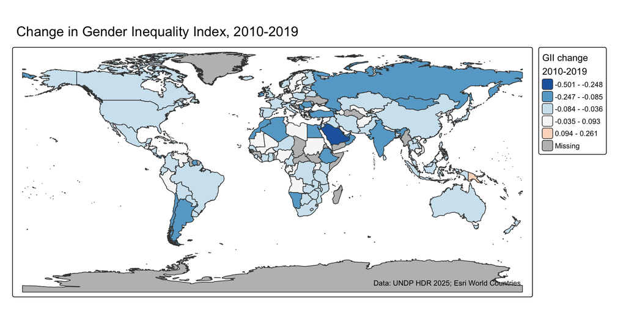

```r
library(tmap)
tmap_mode("plot")   # static map (not interactive)

# diverging colours centred on 0: blue = inequality fell, red = it rose
tm_shape(world_gii) +
  tm_polygons(fill = "gii_diff",
              fill.scale = tm_scale_intervals(style = "fisher", midpoint = 0,
                                              values = "-brewer.rd_bu"),
              fill.legend = tm_legend(title = "GII change\n2010-2019",
                                      position = tm_pos_out("right", "center"))) +
  tm_title("Change in Gender Inequality Index, 2010-2019") +
  tm_credits("Data: UNDP HDR 2025; Esri World Countries")
```

## 5. Interpretation Most countries with data saw their Gender Inequality Index fall between 2010 and 2019 (shown in blue), meaning gender inequality decreased. Only a few countries saw an increase (red).

Limitations: countries in grey have no GII value for 2010 or 2019, so the change could not be calculated. The class breaks (Fisher) also affect how strong the changes look on the map.